# AD1/CDD - Lab. 03 pt. 04

Francisco E. Júnior, André Goncalves

4 de junho de 2019

# Introdução

Iremos explorar um conjunto de dados da 1a. divisão do campeonato brasileiro de futebol de 2017, no intuito de responder algumas perguntas específicas.

# Perguntas

Para responder as perguntas abaixo, inicialmente iremos importar o dataset, assim:

```r
set.seed(1234)
jogos_brasileirao_2017 = readr::read_csv2(here::here("data/data.csv"))
```

## 1. Jogos aos domingos têm mais gols que jogos às quartas?

### 1.a. ICs

```r
comparacao1 = jogos_brasileirao_2017 %>% filter(Dia %in% c("Domingo", "Quarta-feira"))

theta_gols <- function(data, i) {
    agrupado = data %>%
        slice(i) %>%
        group_by(Dia) %>%
        summarise(gols = mean(gols))

    domingos = agrupado %>% filter(Dia == "Domingo") %>% pull(gols)
    quartas = agrupado %>% filter(Dia == "Quarta-feira") %>% pull(gols)
    domingos - quartas
}

theta_gols(comparacao1, i = 1:NROW(comparacao1))
```

```
## [1] -0.01482372
```

```r
ci1 = boot(data = comparacao1,
           statistic = theta_gols,
           R = 2000) %>%
    tidy(conf.level = .95,
         conf.method = "bca",
         conf.int = TRUE)
ci1
```

| statistic | bias | std.error | conf.low | conf.high |
| --- | --- | --- | --- | --- |
| -0.01482372 | -0.002224726 | 0.2166222 | -0.4456392 | 0.4075279 |

### 1.b. Testes de Hipótese

```r
domingos_quartas = jogos_brasileirao_2017 %>% filter(Dia %in% c("Domingo", "Quarta-feira"))

theta_embaralhado = function(d){
    dias = d %>%
        mutate(dia_embaralhado = sample(Dia, n())) %>%
        group_by(dia_embaralhado) %>%
        summarise(gols = mean(gols))

    domingos = dias %>% filter(dia_embaralhado == "Domingo") %>% pull(gols)
    quartas = dias %>% filter(dia_embaralhado == "Quarta-feira") %>% pull(gols)

    domingos - quartas
}

theta_embaralhado(domingos_quartas)
```

```
## [1] 0.108734
```

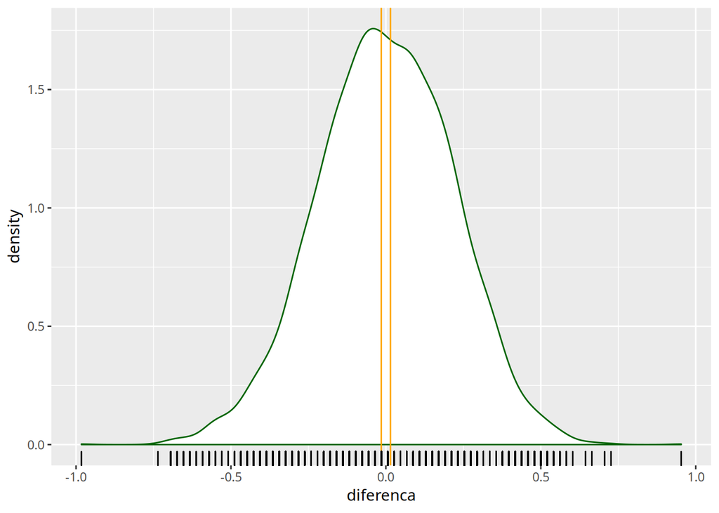

```r
diffs1 = replicate(5000, {theta_embaralhado(domingos_quartas)})

tibble(diferenca = diffs1) %>%
  ggplot(aes(x = diferenca)) +
    geom_density(fill = "white", color = "darkgreen") +
  geom_vline(xintercept = theta_gols(domingos_quartas, 1:NROW(domingos_quartas)), color = "orange") +
  geom_vline(xintercept = - theta_gols(domingos_quartas, 1:NROW(domingos_quartas)), color = "orange") +
  geom_rug()
```

```r
mean(abs(diffs1) >= abs(theta_gols(domingos_quartas, 1:NROW(domingos_quartas))))
```

```
## [1] 0.9614
```

### 1.c. Comparação

Comparando as respostas dos dois métodos, podemos ver que elas concordam entre si, por testes de hipóstese foi calculado um p valor de 0.96, que é alto e significa que não se descarta a hipótese nula, ou seja a diferença é muito pouco significante. Para a análise de intervalo de confiança é visto que a diferença de gols também é pouco significante, com um intervalo de confiança [-0.446; 0.41] com 95% de confiança, que significa que se há uma diferença entre os gols no domingo com os da quarta ela é insignificante (menos de 0.5 gols de diferença) com 95% de confiança. Olhando para análise com intervalo de confiança vemos que ela traz mais informações que a de teste de hipótese, pois além de dizer se o resultado é significante ou não, a análise traz também o intervalo de confiança com sua magnitude. Portanto uma diferença de gols entre os domingos e as quartas, em média, pode existir, mas caso exista é muito pequena, insignificante.

## 2. Jogos onde há um vitorioso têm mais ou menos gols que empates?

### 2.a. ICs

Adicionando uma coluna para identificar se um determinado jogo foi empate ou não:

```r
foi_empate = function(col) {col == 'Empate'}

jogos_brasileirao_2017 = jogos_brasileirao_2017 %>% mutate(Empate = foi_empate(`Vencedor Estado`))
```

Agora, calculando a média na nossa amostra agrupando pela nova coluna:

```r
theta_diff_gols = function(d, i) {
    gols = d %>%
        slice(i) %>%
        group_by(Empate) %>%
        summarise(media_gols = mean(gols))

    media_gols_vitoriosos = gols %>% filter(Empate == FALSE) %>% pull(media_gols)
    media_gols_empates = gols %>% filter(Empate == TRUE) %>% pull(media_gols)

    media_gols_vitoriosos - media_gols_empates
}

theta_c_gols = theta_diff_gols(jogos_brasileirao_2017, 1:NROW(jogos_brasileirao_2017))

theta_c_gols
```

```
## [1] 0.56181
```

Na nossa amostra, temos uma média de 0.56181 gols a mais nos jogos que terminaram com vitoriosos quando comparado com jogos que terminaram em empate.

```r
jogos_brasileirao_2017 %>%
    boot(statistic = theta_diff_gols, R = 4000) %>%
    tidy(conf.level = 0.95,
         conf.int = TRUE)
```

| statistic | bias | std.error | conf.low | conf.high |
| --- | --- | --- | --- | --- |
| 0.56181 | 0.00302061 | 0.1736105 | 0.2209929 | 0.9102878 |

### 2.b. Teste de Hipotése

Agora, vamos fazer a mesma análise utilizando testes de hipótese.

```r
theta_embaralhado_empates = function(d) {
    gols = d %>%
        mutate(empates_embaralhado = sample(Empate, n())) %>%
        group_by(empates_embaralhado) %>%
        summarise(media_gols = mean(gols))

    media_gols_vitoriosos = gols %>% filter(empates_embaralhado == FALSE) %>% pull(media_gols)
    media_gols_empates = gols %>% filter(empates_embaralhado == TRUE) %>% pull(media_gols)

    media_gols_vitoriosos - media_gols_empates
}

theta_embaralhado_empates(jogos_brasileirao_2017)
```

```
## [1] 0.002418422
```

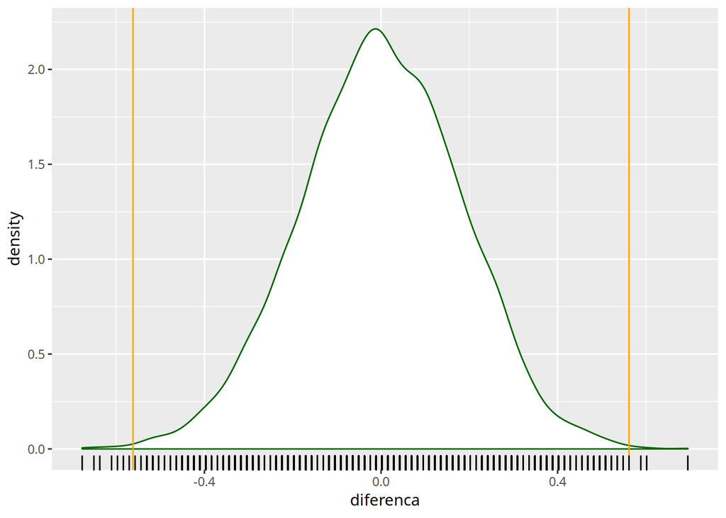

```r
diffs2 = replicate(5000, {theta_embaralhado_empates(jogos_brasileirao_2017)})

tibble(diferenca = diffs2) %>%
  ggplot(aes(x = diferenca)) +
    geom_density(fill = "white", color = "darkgreen") +
  geom_vline(xintercept = theta_diff_gols(jogos_brasileirao_2017, 1:NROW(jogos_brasileirao_2017)), color = "orange") +
  geom_vline(xintercept = - theta_diff_gols(jogos_brasileirao_2017, 1:NROW(jogos_brasileirao_2017)), color = "orange") +
  geom_rug()
```

```r
mean(abs(diffs2) >= abs(theta_diff_gols(jogos_brasileirao_2017, 1:NROW(jogos_brasileirao_2017))))
```

```
## [1] 0.0022
```

Notamos um p-valor extremamente baixo (0.0022), o que faz com que possamos desconsiderar a hipótese nula (i.e. a hipótese de que não há diferença de gols em jogos que terminam com vitoriosos ou empatados).